# 8.4

Kwon Yonghan

2019 5 28

# 8.4.2 Compare Diversities Among Groups

데이터 부르기

```r
abund_table<-read.csv('C:/Users/yongh/Documents/R/R-lab/data/VdrGenusCounts.csv',row.names = 1,check.names=F)
abund_table<-t(abund_table)
Grouping<-data.frame(row.names = rownames(abund_table),t(as.data.frame(strsplit(rownames(abund_table),"_"))))
Grouping$Location<-with(Grouping,ifelse(X3%in%"drySt-28F","Fecal","Cecal"))
Grouping$Group<-with(Grouping,ifelse(as.factor(X2)%in%c(11,12,13,14,15),c("Vdr-/-"),c("WT")))
library(vegan)
CH<-estimateR(abund_table)[2,]
df_CH<-data.frame(sample=names(CH),value=CH,measure=rep("Chaol",length(CH)))
df_CH_G<-cbind(df_CH,Grouping)
rownames(df_CH_G)<-NULL
df_CH_G$Group4<-with(df_CH_G,interaction(Location,Group))
df_CH_G
```

```
##            sample     value measure X1 X2        X3 Location  Group
## 1  5_15_drySt-28F  94.75000   Chaol  5 15 drySt-28F    Fecal Vdr-/-
## 2  20_12_CeSt-28F  59.80000   Chaol 20 12  CeSt-28F    Cecal Vdr-/-
## 3  1_11_drySt-28F  77.00000   Chaol  1 11 drySt-28F    Fecal Vdr-/-
## 4  2_12_drySt-28F 103.27273   Chaol  2 12 drySt-28F    Fecal Vdr-/-
## 5  3_13_drySt-28F  85.66667   Chaol  3 13 drySt-28F    Fecal Vdr-/-
## 6  4_14_drySt-28F  55.14286   Chaol  4 14 drySt-28F    Fecal Vdr-/-
## 7  7_22_drySt-28F  62.75000   Chaol  7 22 drySt-28F    Fecal     WT
## 8  8_23_drySt-28F  67.66667   Chaol  8 23 drySt-28F    Fecal     WT
## 9  9_24_drySt-28F  80.50000   Chaol  9 24 drySt-28F    Fecal     WT
## 10 19_11_CeSt-28F  52.16667   Chaol 19 11  CeSt-28F    Cecal Vdr-/-
## 11 21_13_CeSt-28F  55.00000   Chaol 21 13  CeSt-28F    Cecal Vdr-/-
## 12 22_14_CeSt-28F  59.00000   Chaol 22 14  CeSt-28F    Cecal Vdr-/-
## 13 23_15_CeSt-28F  60.87500   Chaol 23 15  CeSt-28F    Cecal Vdr-/-
## 14 25_22_CeSt-28F  51.00000   Chaol 25 22  CeSt-28F    Cecal     WT
```

[output cut: 19 more lines]

데이터 준비

```r
#Vdr-/- mouse data
library(dplyr)
data<-mutate(df_CH_G,Group=factor(df_CH_G$Group4,levels=unique(df_CH_G$Group4)))
```

Obtain Descriptive Statistics

```r
library(FSA)
Summarize(value~Group4,data=df_CH_G)
```

```
##         Group4 n     mean        sd      min       Q1   median       Q3
## 1 Cecal.Vdr-/- 5 57.36833  3.658497 52.16667 55.00000 59.00000 59.80000
## 2 Fecal.Vdr-/- 5 83.16645 18.493505 55.14286 77.00000 85.66667 94.75000
## 3     Cecal.WT 3 80.63866 31.009163 51.00000 64.52941 78.05882 95.45798
## 4     Fecal.WT 3 70.30556  9.164520 62.75000 65.20833 67.66667 74.08333
##        max
## 1  60.8750
## 2 103.2727
## 3 112.8571
## 4  80.5000
```

Generate Histogram by Group

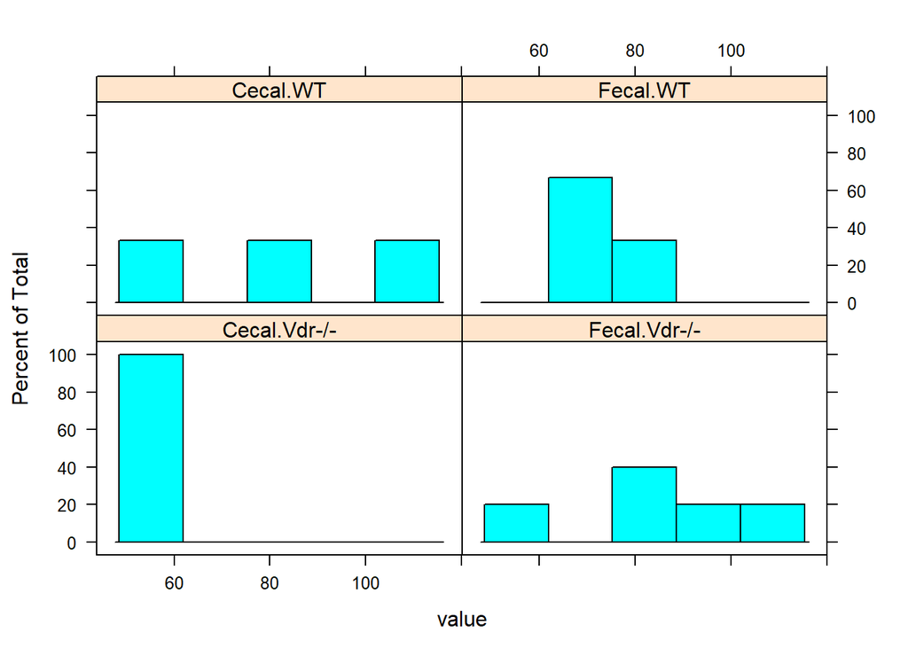

```r
#Individual plots in panel of 2 columns and 2 rows
library(lattice)
histogram(~value|Group4, data=df_CH_G,layout=c(2,2))
```

Kruskal wallis test of Chao 1 richness

```r
kruskal.test(value~Group4,data = df_CH_G)
```

```
##
##  Kruskal-Wallis rank sum test
##
## data:  value by Group4
## Kruskal-Wallis chi-squared = 5.2353, df = 3, p-value = 0.1554
```

```r
qchisq(0.95,3)
```

```
## [1] 7.814728
```

```r
library("DescTools")
#Tukey method for adjusting p-values
Test_N <- NemenyiTest(x=df_CH_G$value,g=df_CH_G$Group4,dist="tukey")
Test_N
```

```
##
##  Nemenyi's test of multiple comparisons for independent samples (tukey)
##
##                           mean.rank.diff   pval
## Fecal.Vdr-/--Cecal.Vdr-/-      6.6000000 0.1254
## Cecal.WT-Cecal.Vdr-/-          4.7333333 0.5237
## Fecal.WT-Cecal.Vdr-/-          5.0666667 0.4636
## Cecal.WT-Fecal.Vdr-/-         -1.8666667 0.9501
## Fecal.WT-Fecal.Vdr-/-         -1.5333333 0.9713
## Fecal.WT-Cecal.WT              0.3333333 0.9998
## ---
## Signif. codes:  0 '***' 0.001 '**' 0.01 '*' 0.05 '.' 0.1 ' ' 1
```

Dunn Test for Multiple Comparisons

```r
Test_N<-dunnTest(df_CH_G$value~df_CH_G$Group4,data=df_CH_G,method="bh")
Test_N
```

```
## Dunn (1964) Kruskal-Wallis multiple comparison
```

```
##   p-values adjusted with the Benjamini-Hochberg method.
```

```
##                    Comparison           Z    P.unadj     P.adj
## 1     Cecal.Vdr-/- - Cecal.WT -1.36136286 0.17339905 0.3467981
## 2 Cecal.Vdr-/- - Fecal.Vdr-/- -2.19189684 0.02838696 0.1703217
## 3     Cecal.WT - Fecal.Vdr-/- -0.53687549 0.59135362 0.8870304
## 4     Cecal.Vdr-/- - Fecal.WT -1.45723348 0.14505194 0.4351558
## 5         Cecal.WT - Fecal.WT -0.08574929 0.93166572 0.9316657
## 6     Fecal.Vdr-/- - Fecal.WT  0.44100487 0.65920947 0.7910514
```

# 8.4.3 Find Significant Taxa Among Groups

fecal과 cecal에서 Vdr-/-, WT 쥐를 비교해 눈에띄는 taxa 차이가 있는지 확인하자.

log 정규화

```r
data<-log((abund_table+1)/(rowSums(abund_table)+dim(abund_table)[2]))
df<-as.data.frame(data)
kruskal.test(df[,1],g=df_CH_G$Group4)
```

```
##
##  Kruskal-Wallis rank sum test
##
## data:  df[, 1] and df_CH_G$Group4
## Kruskal-Wallis chi-squared = 12.718, df = 3, p-value = 0.005289
```

taxa 비율 정규화

```r
df<-as.data.frame(abund_table/rowSums(abund_table))
```

248개 각각의 박테리아의 kruskal.test() 진행

```r
KW_table<-data.frame()
for(i in 1:dim(df)[2]){
  KW_test<-kruskal.test(df[,i],g=df_CH_G$Group4)
  KW_table<-rbind(KW_table,
                  data.frame(id=names(df)[i],p.value=KW_test$p.value))
  cat(paste("Kruskal-Wallis test for",names(df)," ",i,"/",dim(df)[2],"; p-value",KW_test$p.value,
            "\n",sep=""))
}
```

```r
head(KW_table)
```

```
##                           id     p.value
## 1                 Tannerella 0.005288755
## 2                Lactococcus 0.353414883
## 3              Lactobacillus 0.066829264
## 4 Lactobacillus::Lactococcus 0.476355094
## 5             Parasutterella 0.231291869
## 6               Helicobacter 0.025105786
```

# 8.4.4 Multiple Testing and E-value, FWER and FDR

## 8.4.4.1 E-value

E-value는 multiple test를 시행했을 때 우연한 false positive(1종 오류)의 기댓값이다.  
E-value = p-value * the number of test.  
E-value의 기준 보정은 명목상의 p-value보다 test에서의 p-value라는 것을 알고 있어라.  
E-value가 p-value를 시험의 갯수를 곱하는거니까 1보다 클 수 있다.

```r
KW_table$E.value<-KW_table$p.value*dim(KW_table)[1]
KW_table$E.value
```

```
##   [1]   1.3116113  87.6468909  16.5736575 118.1360634  57.3603836
##   [6]   6.2262348   1.4634253   0.9859927   9.9526711   1.0990188
##  [11] 143.4763361 180.4735421  27.7505026   8.1685154   2.5256148
##  [16]  26.4295901   6.5275347  22.0246562   0.9769917  56.4564840
##  [21]  92.2886474 194.1549699   1.1790332  40.2004531 179.8181618
##  [26]  31.0408439  15.2885971 223.0019856   6.0955351 131.9231961
##  [31]  72.1794358         NaN  77.4613319  32.0936266 131.9231961
##  [36]  38.3345475  77.0818279  53.7715280   1.3334616 157.7199666
##  [41] 131.9231961   4.3563543  55.9955976 131.9231961  34.0040285
##  [46] 131.9231961  56.4564840  38.8566762  90.9779701  82.1552678
##  [51] 151.3993679  39.0298190 152.8215277 131.9231961  15.3487778
##  [56]  21.6900505 181.2177535  17.1835622 243.7299541 109.9706997
##  [61]   6.0727392  77.0818279   8.3869079 131.9231961 125.1871541
##  [66]         NaN   3.7903600  38.4742113  94.5325720 181.2177535
##  [71]         NaN  15.7559128 131.9231961   2.5335259  62.9557217
```

[output cut: 35 more lines]

```r
head(KW_table)
```

```
##                           id     p.value    E.value
## 1                 Tannerella 0.005288755   1.311611
## 2                Lactococcus 0.353414883  87.646891
## 3              Lactobacillus 0.066829264  16.573657
## 4 Lactobacillus::Lactococcus 0.476355094 118.136063
## 5             Parasutterella 0.231291869  57.360384
## 6               Helicobacter 0.025105786   6.226235
```

## 8.4.4.2 FWER

FWER는 false postive(type 1 error)를 만들 확률을 의미한다.  
다른말로 하면 영가설을 기각하지 못 할 확률을 의미한다.  
H_0 : multiple test를 진행 했을 때 group간의 차이가 없다.  
FWER = 1-(1-p-value)^T, T = number of test

```r
KW_table$FWER<-pbinom(q=0,p=KW_table$ p.value,size=dim(KW_table)[1],
                      lower.tail = F)
```

## 8.4.4.3 FDR

FDR = 잘못된 기각/모든 기각  
Benjamini_hochberg correction은 다음과 같은 순서를 따른다.  
1. p-value를 작은 것에서부터 rank를 매긴다.

```r
KW_table<-KW_table[order(KW_table$p.value,decreasing = F),]
head(KW_table)
```

```
##                id     p.value   E.value      FWER
## 19      Alistipes 0.003939483 0.9769917 0.6242838
## 8     Bacteroides 0.003975777 0.9859927 0.6276638
## 10    Odoribacter 0.004431527 1.0990188 0.6676149
## 23 Paraprevotella 0.004754166 1.1790332 0.6932876
## 1      Tannerella 0.005288755 1.3116113 0.7315504
## 39  Butyricimonas 0.005376861 1.3334616 0.7373832
```

q-value = p-value * T/k

```r
KW_table$q.value.factor<-dim(KW_table)[1]/1:dim(KW_table)[1]
head(KW_table$q.value.factor)
```

```
## [1] 248.00000 124.00000  82.66667  62.00000  49.60000  41.33333
```

```r
KW_table$q.value<-KW_table$p.value*KW_table$q.value.factor
head(KW_table$q.value)
```

```
## [1] 0.9769917 0.4929964 0.3663396 0.2947583 0.2623223 0.2222436
```

```r
head(KW_table)
```

```
##                id     p.value   E.value      FWER q.value.factor   q.value
## 19      Alistipes 0.003939483 0.9769917 0.6242838      248.00000 0.9769917
## 8     Bacteroides 0.003975777 0.9859927 0.6276638      124.00000 0.4929964
## 10    Odoribacter 0.004431527 1.0990188 0.6676149       82.66667 0.3663396
## 23 Paraprevotella 0.004754166 1.1790332 0.6932876       62.00000 0.2947583
## 1      Tannerella 0.005288755 1.3116113 0.7315504       49.60000 0.2623223
## 39  Butyricimonas 0.005376861 1.3334616 0.7373832       41.33333 0.2222436
```

특정한 alpha 보다 낮은 것이 있는지 확인.  
지금은 없다.

```r
KW_alpha=0.05
last.significant.item<-max(which(KW_table$q.value<=KW_alpha))
last.significant.item
```

```
## [1] -Inf
```

```r
selected<-1:5
print(KW_table[selected,])
```

```
##                id     p.value   E.value      FWER q.value.factor   q.value
## 19      Alistipes 0.003939483 0.9769917 0.6242838      248.00000 0.9769917
## 8     Bacteroides 0.003975777 0.9859927 0.6276638      124.00000 0.4929964
## 10    Odoribacter 0.004431527 1.0990188 0.6676149       82.66667 0.3663396
## 23 Paraprevotella 0.004754166 1.1790332 0.6932876       62.00000 0.2947583
## 1      Tannerella 0.005288755 1.3116113 0.7315504       49.60000 0.2623223
```

```r
diff.taxa.factor<-KW_table$id[selected]
diff.taxa<-as.vector(diff.taxa.factor)
diff.taxa
```

```
## [1] "Alistipes"      "Bacteroides"    "Odoribacter"    "Paraprevotella"
## [5] "Tannerella"
```